# TP Fondamentaux du data mining

Trésor Djonga

31/01/2020

## Data mining exploratoire avec kmeans

Chargement de la table conso

```r
load("C:\\Users\\Djonga\\Desktop\\DU BIG DATA\\M2\\J1\\conso.rdata")
```

Affichage des dix premièrs unités statistiques cad les dix premiers jours de l’année

```r
conso[1:10,]
```

```
##          date X00h00 X00h10 X00h20 X00h30 X00h40 X00h50 X01h00 X01h10
## 1  2007-01-01 2.5308 2.4788 2.6230 2.6280 2.5696 2.4736 2.5586 2.5356
## 2  2007-01-02 0.3764 0.3722 0.4188 0.5964 0.4778 0.4370 0.3942 0.5316
## 3  2007-01-03 1.2226 0.5320 0.4666 1.5398 1.4926 1.4990 1.4686 1.5290
## 4  2007-01-04 0.8440 2.7834 5.4690 5.1444 3.2982 2.7114 2.4878 3.4464
## 5  2007-01-05 1.1728 1.1486 1.7876 2.2382 2.3954 3.0656 2.3916 2.4844
## 6  2007-01-06 1.7068 1.6440 1.5058 1.4168 1.3722 1.3128 1.1250 0.2900
## 7  2007-01-07 1.5102 1.3484 1.3192 0.6436 0.3560 0.2418 0.2426 0.3436
## 8  2007-01-08 1.3666 1.3558 1.3960 1.3788 1.3198 1.3458 1.4106 1.3578
## 9  2007-01-09 0.2872 0.2426 0.2756 0.2834 0.3094 0.2208 0.2758 0.2736
## 10 2007-01-10 0.3416 0.2974 0.2426 0.4040 0.3258 1.4960 1.3128 1.4302
##    X01h20 X01h30 X01h40 X01h50 X02h00 X02h10 X02h20 X02h30 X02h40 X02h50
## 1  2.5422 2.4656 2.5482 2.4902 2.5482 2.5584 2.6060 2.5180 2.6096 2.6538
## 2  0.4202 0.3752 0.3790 0.5202 0.4462 0.3834 0.3846 0.5094 0.4704 0.3954
## 3  1.3946 0.4298 0.2896 0.2926 0.2714 0.3506 0.3068 0.2900 0.2790 0.3312
```

[output cut: 150 more lines]

Pour les dix premiers jours de l’année, sont affichés les 12 premières variables en excluant l’identifiant des jours.

```r
conso[1:10,2:13]
```

```
##    X00h00 X00h10 X00h20 X00h30 X00h40 X00h50 X01h00 X01h10 X01h20 X01h30
## 1  2.5308 2.4788 2.6230 2.6280 2.5696 2.4736 2.5586 2.5356 2.5422 2.4656
## 2  0.3764 0.3722 0.4188 0.5964 0.4778 0.4370 0.3942 0.5316 0.4202 0.3752
## 3  1.2226 0.5320 0.4666 1.5398 1.4926 1.4990 1.4686 1.5290 1.3946 0.4298
## 4  0.8440 2.7834 5.4690 5.1444 3.2982 2.7114 2.4878 3.4464 4.3042 2.2970
## 5  1.1728 1.1486 1.7876 2.2382 2.3954 3.0656 2.3916 2.4844 2.4320 2.3652
## 6  1.7068 1.6440 1.5058 1.4168 1.3722 1.3128 1.1250 0.2900 0.3036 0.2546
## 7  1.5102 1.3484 1.3192 0.6436 0.3560 0.2418 0.2426 0.3436 0.3716 0.2460
## 8  1.3666 1.3558 1.3960 1.3788 1.3198 1.3458 1.4106 1.3578 1.3292 1.3112
## 9  0.2872 0.2426 0.2756 0.2834 0.3094 0.2208 0.2758 0.2736 0.3956 0.3304
## 10 0.3416 0.2974 0.2426 0.4040 0.3258 1.4960 1.3128 1.4302 0.4382 0.2254
##    X01h40 X01h50
## 1  2.5482 2.4902
## 2  0.3790 0.5202
## 3  0.2896 0.2926
## 4  2.4024 2.4426
## 5  2.2882 2.3596
## 6  0.3414 0.2862
## 7  0.2462 0.3286
## 8  1.3730 1.3222
## 9  0.3016 0.2940
## 10 0.2244 0.2924
```

On trace la courbe de la consommation pour le cinquième jour de l’année (2007-01-05).

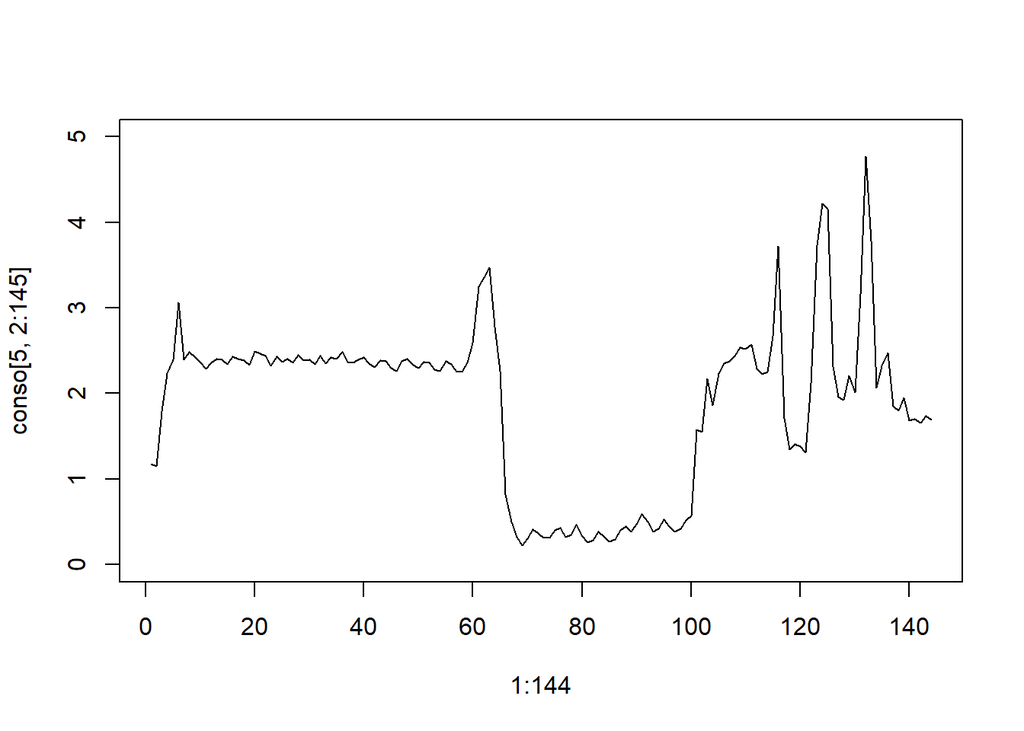

```r
par(mfrow=c(1,1))
plot(1:144,conso[5,2:145],ylim=c(0,5),type="l")
```

On choisit de manière aléatoire 12 jours dans l’année,et on affiche la courbe la courbe de consommation pour chacune d’elle.

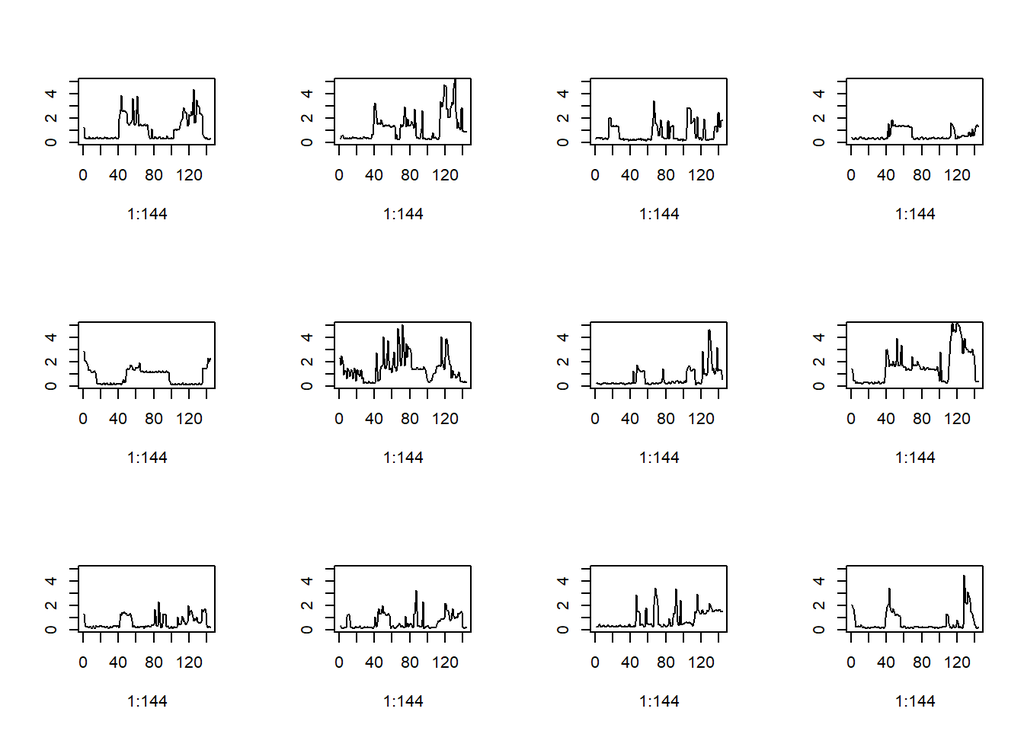

```r
par(mfrow=c(3,4))
for (i in sample(1:349,12))
   plot(1:144,conso[i,2:145],ylab="",ylim=c(0,5),type="l")
```

conso[,2:145]: data set sur lequel la classification est faite.

centers=12: On fait une classification avec 12 classes. Les centroïdes sont choisies de manière aléatoire.

nstart=10: A chaque fois on choisit 10 lignes dans la base conso et on les affectes dans une de 12 classes.

iter.max=50 le nombre maximum d’itération, au délà de laquelle l’algorithme s’arrête même si la convergence n’a pas été atteinte.

algorithm=c(“MacQueen”): L’algorithme specifique de MacQueen est chosi pour réaliser le k-means.

```r
res_clus<-kmeans(conso[,2:145],centers=12,nstart=10, iter.max=50,algorithm=c("MacQueen"))
```

Donne la classe dans laquelle appartient chaque jour de la semaine, les classes sont numérotés de 1 à 12.

```r
res_clus$cluster
```

```
##   [1]  2 11  7  2  2 10  6 11 11  3 11  9  6  3 11  6 11  4  6  6  3 11  2
##  [24] 11  1  5  3 11  5  9  9  2  2  1  1  5  3  1  6  2  1 11  5  3  9  9
##  [47]  2  3  2 11  7  8  8  8  8  8  8  8  8 11 11  1  3 12  7  6  2  3  9
##  [70]  3  3  9  3  3  3 12  5  4  4  6  1 12  5 12  1  6  6 12  9  5 12  9
##  [93]  4  7  8  8  7  8  8  8  8  4  4  4  8  4  3  5  1  4  4  1  4  3  4
## [116]  4  4 10  9  1  5  3  8  4  1 10 12  8  1  4  3 10  3  4  4  1  4 12
## [139] 10  5  3  4  1  4 10  5  8  9  1  8  5  8 10  8  8  8  9  8  3 11  8
## [162]  8 12  4  8  8  8  4  4 12  3 11  8  4  4  8  4 12  4  8  4  4  8 12
## [185]  8 10  4  8  8  8  8  8  8  8  8  8  8  4 10  8  8  8  7  7  7  7  7
## [208]  7 10  7  7  7  7  7  7  7  7  7  8  8 11 10  8  9  8 10 10  4  8  8
## [231]  9  1 11 10  1  3  4  4  1 11  3 12  4  4  4  4  4  3 12  4 11  4 12
## [254]  1  3 11  1  1  1  5  3  9  5  1  1  1  3  3  4 11 12 12  3  3  5  1
## [277]  5  1 12  5 10  5  1  3 12  1  7  8 10 10  8 10  8 11  9  5 11 12  5
## [300]  6  3  3 11  5  1  5  6  3  3  3  3  5 10  3  1  5  1  1  5  6  5  9
## [323]  5  3  3 10  3 11 11  5 11  3  5  6  5  5  5  5  3  6  6  5  6  5  6
## [346]  6  2  6  5
```

Affichage les coordonnées des centroïdes des 12 classes.

```r
res_clus$centers
```

```
##       X00h00    X00h10    X00h20    X00h30    X00h40    X00h50    X01h00
## 1  0.6359412 0.5096235 0.5179176 0.5132765 0.4654353 0.4092235 0.3953176
## 2  2.5534364 3.0000727 3.4686182 3.5370909 3.1374000 2.9600182 2.8064909
## 3  0.6661500 0.6259909 0.5282227 0.5286045 0.6168591 0.5181909 0.4462545
## 4  0.7886186 0.7104000 0.6125209 0.5611256 0.5471767 0.5609535 0.5374651
## 5  0.8908833 0.8210222 0.7566167 0.6827556 0.7581222 0.6284778 0.6376167
## 6  0.8102200 0.9539900 0.8388300 0.6689100 0.6179500 0.5675000 0.5693700
## 7  1.5708000 1.4277143 1.3284190 1.2512762 1.0942286 1.0582667 1.0345048
## 8  0.5673321 0.5079857 0.4742607 0.4347643 0.4224643 0.3849393 0.3332536
## 9  0.9106235 0.7956353 0.7125882 0.6302824 0.6222118 0.5667059 0.5390000
## 10 1.3953200 1.2893400 0.8307100 0.7178100 0.6555700 0.7059200 0.5478000
## 11 0.5694667 0.5118815 0.4950222 0.4607852 0.4588000 0.4099630 0.3945852
## 12 0.7022200 0.4859300 0.3983000 0.3767700 0.3908900 0.4521000 0.4531000
##       X01h10    X01h20    X01h30    X01h40    X01h50    X02h00    X02h10
## 1  0.3683471 0.3502529 0.3284471 0.3341882 0.3342588 0.3326059 0.2946882
```

[output cut: 258 more lines]

La taille (le nombre des jours) dans chaqu’une de 12 clusters.

```r
res_clus$size
```

```
##  [1] 34 11 44 43 36 20 21 56 17 20 27 20
```

On relance les kmeans pour former 6 classes.

```r
res_clus<-kmeans(conso[,2:145],centers=6,nstart=10, iter.max=50,algorithm=c("MacQueen"))
```

On trace la courbe de consommation des centroïdes pour les 6 classe.

classe 2: La classe des jours de l’année où une activité jusque tard dabs la nuit(la visite des amis, une fête,…).

classe 6: La classe des jours de l’année où il est resté ou a travaillé tard.

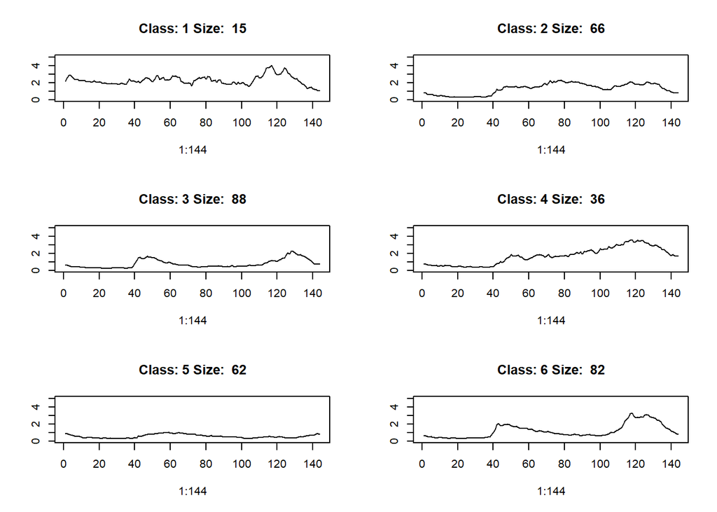

```r
par(mfrow=c(3,2))
for (i in 1:dim(res_clus$centers)[1])
  plot(1:144,res_clus$centers[i,],type="l",ylab="",ylim=c(0,5),
       main=paste("Class:",i,"Size: ",res_clus$size[i]))
```

classe 3: La classe des jours où il est sorti toute la semaine sauf les week ends ou il est absent.

classe 6: il a passé les week end chez les amis.

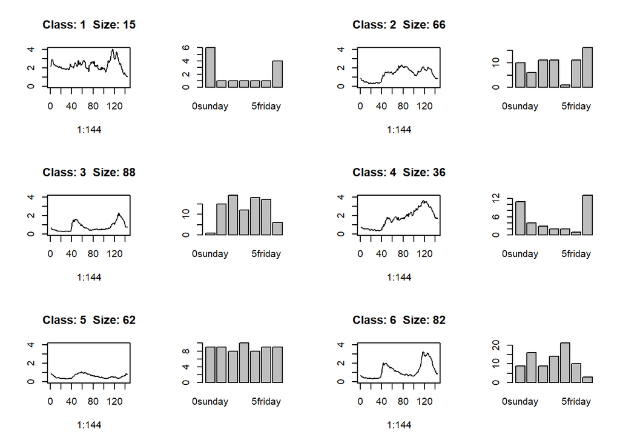

```r
weekdays<-c("0sunday","1monday","2tuesday","3wednesday","4thursday","5friday",
            "6saturday")
res_clus_6<- res_clus$cluster
par(mfrow=c(3,4))
for (i in 1:6) {
  plot(1:144,sapply(conso[res_clus_6==i,2:145],mean),type="l",
       ylab="",ylim=c(0,4),
       main=paste("Class:",i," Size:",
                  length(res_clus_6[res_clus_6==i])))
  barplot(table(weekdays[conso[res_clus_6==i,]$weekday+1]))
}
```

##Méthodologie d’évaluation d’une méthode de prédiction

```r
?iris
```

```
## starting httpd help server ... done
```

```r
data(iris)
```

Oui au vu de ces variables, il est possible de discriminer les classes à l’aide des variables predictives. On constant les valeurs plus grandes pour le virginica à l’exception sepal.width, ce qui est exactement contraire pour le setosa. Le versicolor se situe entre les deux.

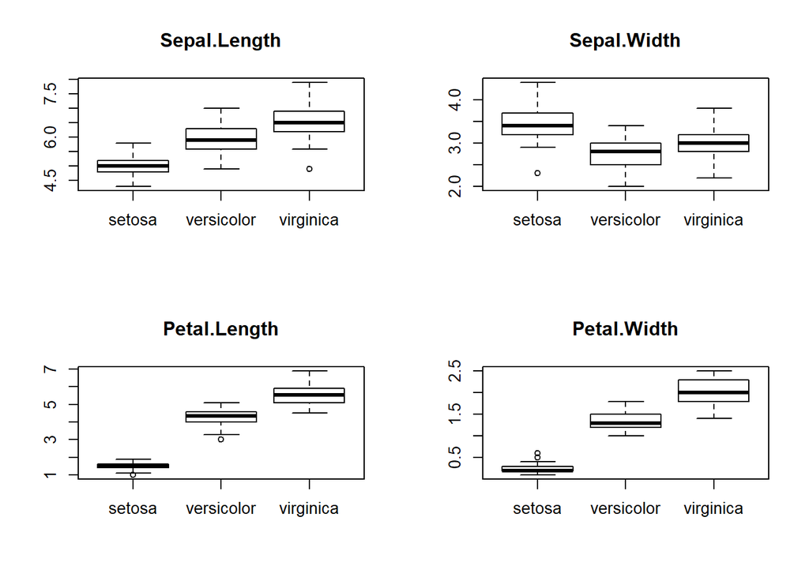

```r
par(mfrow=c(2,2))

for (i in 1:4){
      boxplot(iris[,i] ~ iris$Species)
      title(main=dimnames(iris)[[2]][i])
}
```

On tire de manière aléatoire avec remplacement les individus dans la base iris pour obtenir un échantillon échantillon d’apprntissage de 80% et de test de 20%.

```r
set.seed(1234)
ind <- sample(2, nrow(iris), replace=TRUE, prob=c(0.8, 0.2))
iris.train <- iris[ind==1,]
iris.test <- iris[ind==2,]
```

On tire de maniere aleatoire 130 individu dans la base comme base d’apprentissage soit 86% et le complement est prit comme base test.

```r
ech<-sample(1:150,130)
iris.train<-iris[ech,]
iris.test<-iris[-ech,]
```

L’analyse discriminante est utilisé pour predire une variable qualitative avec un nombre des catégoris fixe à l’aide des prédicteurs.

```r
library(MASS)
?lda
```

```r
z<-lda(Species ~ ., iris.train)
```

Calcul du taux d’erreur de la prédiction .

```r
iris.predit<-predict(z,iris.test)$class
table_pre<-table(iris.test$Species,iris.predit)
t <-0
#taux de prédiction
  for (j in 1:dim(table_pre)[1]){
    for (k in 1:dim(table_pre)[2])
    {
      if (i!=k){
        t <- t + table_pre[j,k]
      }
    }
  }
  print(paste("Le taux d'erreur est de ",t/sum(table_pre)))
```

```
## [1] "Le taux d'erreur est de  1"
```

L’algorithme suivant de validation croisée : Répéter 50 fois { Tirer au hasard 130 individus pour constituer l’échantillon d’apprentissage (train) (les 20 restants formant l’échantillon test) Construire le modèle avec l’échantillon d’apprentissage Calculer le taux d’erreur sur l’échantillon test et le mémoriser } Calculer la moyenne et l’écart type des 50 taux d’erreur obtenus.

```r
t <- 0
table_error <- c()

for (i in 1:50){
  #Echantillonage: séparation data set en train et  test
  ech<-sample(1:150,130)
  iris.train<-iris[ech,]
  iris.test<-iris[-ech,]

  #Modélisation avec l'analyse discriminante
  z<-lda(Species ~ ., iris.train)

  #Prediction
  iris.predit<-predict(z,iris.test)$class
  table_pre <- table(iris.test$Species,iris.predit)

  #taux de prédiction
  for (j in 1:dim(table_pre)[1]){
    for (k in 1:dim(table_pre)[2])
    {
      if (i!=k){
        t <- t + table_pre[j,k]
      }
    }
  }
  error <- t/sum(table_pre)
  table_error <- c(table_error, error)
  print(paste("Taux d'erreur du modèle numéro :=",i, "est de", t/sum(table_pre)))
}
```

```
## [1] "Taux d'erreur du modèle numéro := 1 est de 0.7"
## [1] "Taux d'erreur du modèle numéro := 2 est de 1.5"
## [1] "Taux d'erreur du modèle numéro := 3 est de 2.2"
## [1] "Taux d'erreur du modèle numéro := 4 est de 3.2"
## [1] "Taux d'erreur du modèle numéro := 5 est de 4.2"
## [1] "Taux d'erreur du modèle numéro := 6 est de 5.2"
## [1] "Taux d'erreur du modèle numéro := 7 est de 6.2"
## [1] "Taux d'erreur du modèle numéro := 8 est de 7.2"
## [1] "Taux d'erreur du modèle numéro := 9 est de 8.2"
## [1] "Taux d'erreur du modèle numéro := 10 est de 9.2"
## [1] "Taux d'erreur du modèle numéro := 11 est de 10.2"
## [1] "Taux d'erreur du modèle numéro := 12 est de 11.2"
## [1] "Taux d'erreur du modèle numéro := 13 est de 12.2"
## [1] "Taux d'erreur du modèle numéro := 14 est de 13.2"
## [1] "Taux d'erreur du modèle numéro := 15 est de 14.2"
```

[output cut: 35 more lines]

```r
print(table_error)
```

```
##  [1]  0.7  1.5  2.2  3.2  4.2  5.2  6.2  7.2  8.2  9.2 10.2 11.2 12.2 13.2
## [15] 14.2 15.2 16.2 17.2 18.2 19.2 20.2 21.2 22.2 23.2 24.2 25.2 26.2 27.2
## [29] 28.2 29.2 30.2 31.2 32.2 33.2 34.2 35.2 36.2 37.2 38.2 39.2 40.2 41.2
## [43] 42.2 43.2 44.2 45.2 46.2 47.2 48.2 49.2
```

```r
print("Moyenne des 50 taux d'erreur")
```

```
## [1] "Moyenne des 50 taux d'erreur"
```

```r
print(mean(table_error))
```

```
## [1] 24.716
```

```r
print("Ecart type 50 taux d'erreur")
```

```
## [1] "Ecart type 50 taux d'erreur"
```

```r
print(sd(table_error))
```

```
## [1] 14.55056
```

```r
t <- 0
table_error <- c()

for (i in 1:50){
  #Echantillonage: séparation data set en train et  test
  ech<-sample(1:150,30)
  iris.train<-iris[ech,]
  iris.test<-iris[-ech,]

  #Modélisation avec l'analyse discriminante
  z<-lda(Species ~ ., iris.train)

  #Prediction
  iris.predit<-predict(z,iris.test)$class
  table_pre <- table(iris.test$Species,iris.predit)

  #taux de prédiction
  for (j in 1:dim(table_pre)[1]){
    for (k in 1:dim(table_pre)[2])
    {
      if (i!=k){
        t <- t + table_pre[j,k]
      }
    }
  }
  error <- t/sum(table_pre)
  table_error <- c(table_error, error)
  print(paste("Taux d'erreur du modèle numéro :=",i, "est de", t/sum(table_pre)))
}
```

```
## [1] "Taux d'erreur du modèle numéro := 1 est de 0.675"
## [1] "Taux d'erreur du modèle numéro := 2 est de 1.35"
## [1] "Taux d'erreur du modèle numéro := 3 est de 2.06666666666667"
## [1] "Taux d'erreur du modèle numéro := 4 est de 3.06666666666667"
## [1] "Taux d'erreur du modèle numéro := 5 est de 4.06666666666667"
## [1] "Taux d'erreur du modèle numéro := 6 est de 5.06666666666667"
## [1] "Taux d'erreur du modèle numéro := 7 est de 6.06666666666667"
## [1] "Taux d'erreur du modèle numéro := 8 est de 7.06666666666667"
## [1] "Taux d'erreur du modèle numéro := 9 est de 8.06666666666667"
## [1] "Taux d'erreur du modèle numéro := 10 est de 9.06666666666667"
## [1] "Taux d'erreur du modèle numéro := 11 est de 10.0666666666667"
## [1] "Taux d'erreur du modèle numéro := 12 est de 11.0666666666667"
## [1] "Taux d'erreur du modèle numéro := 13 est de 12.0666666666667"
## [1] "Taux d'erreur du modèle numéro := 14 est de 13.0666666666667"
## [1] "Taux d'erreur du modèle numéro := 15 est de 14.0666666666667"
```

[output cut: 35 more lines]

```r
print(table_error)
```

```
##  [1]  0.675000  1.350000  2.066667  3.066667  4.066667  5.066667  6.066667
##  [8]  7.066667  8.066667  9.066667 10.066667 11.066667 12.066667 13.066667
## [15] 14.066667 15.066667 16.066667 17.066667 18.066667 19.066667 20.066667
## [22] 21.066667 22.066667 23.066667 24.066667 25.066667 26.066667 27.066667
## [29] 28.066667 29.066667 30.066667 31.066667 32.066667 33.066667 34.066667
## [36] 35.066667 36.066667 37.066667 38.066667 39.066667 40.066667 41.066667
## [43] 42.066667 43.066667 44.066667 45.066667 46.066667 47.066667 48.066667
## [50] 49.066667
```

```r
print("Moyenne des 50 taux d'erreur")
```

```
## [1] "Moyenne des 50 taux d'erreur"
```

```r
print(mean(table_error))
```

```
## [1] 24.5845
```

```r
print("Ecart type 50 taux d'erreur")
```

```
## [1] "Ecart type 50 taux d'erreur"
```

```r
print(sd(table_error))
```

```
## [1] 14.54747
```

## Arbres de décision

```r
library(rpart)
library(rpart.plot)
```

Chargement de la base cardiac

```r
load("C:\\Users\\Djonga\\Desktop\\DU BIG DATA\\M2\\J1\\cardiac.rdata")
```

Statistiques descriptives sur les variables de la base cardiac.

```r
summary(cardiac)
```

```
##       age            sexe                chest_pain  blood_pressure
##  Min.   :29.00   female: 97   typical angina  : 23   Min.   : 94.0
##  1st Qu.:48.00   male  :206   atypical angina : 50   1st Qu.:120.0
##  Median :56.00                non-anginal pain: 86   Median :130.0
##  Mean   :54.44                asymptomatic    :144   Mean   :131.7
##  3rd Qu.:61.00                                       3rd Qu.:140.0
##  Max.   :77.00                                       Max.   :200.0
##
##   cholesterol    blood_sugar                      electrocardio
##  Min.   :126.0   false:258   normal                      :151
##  1st Qu.:211.0   true : 45   wave abnormality            :  4
##  Median :241.0               left ventricular hypertrophy:148
##  Mean   :246.7
##  3rd Qu.:275.0
##  Max.   :564.0
##
##  max_heart_rate  exercise_angina ST_depression   exercice_peak_slope
##  Min.   : 71.0   no :204         Min.   :0.00   upsloping  :142
##  1st Qu.:133.5   yes: 99         1st Qu.:0.00   flat       :140
##  Median :153.0                   Median :0.80   downsloping: 21
##  Mean   :149.6                   Mean   :1.04
##  3rd Qu.:166.0                   3rd Qu.:1.60
##  Max.   :202.0                   Max.   :6.20
##
##  nb_coloured_vessels                thal     disease
##  Min.   :2.000       normal           :166   no :164
##  1st Qu.:2.000       fixed defect     : 18   yes:139
##  Median :2.000       reversable defect:117
##  Mean   :2.672       NA's             :  2
##  3rd Qu.:3.000
##  Max.   :5.000
##  NA's   :4
```

Quelques statistiques descriptives simples de ce tableau, en particulier des diagrammes conditionnellement à l’appartenance à la classe à prédire.

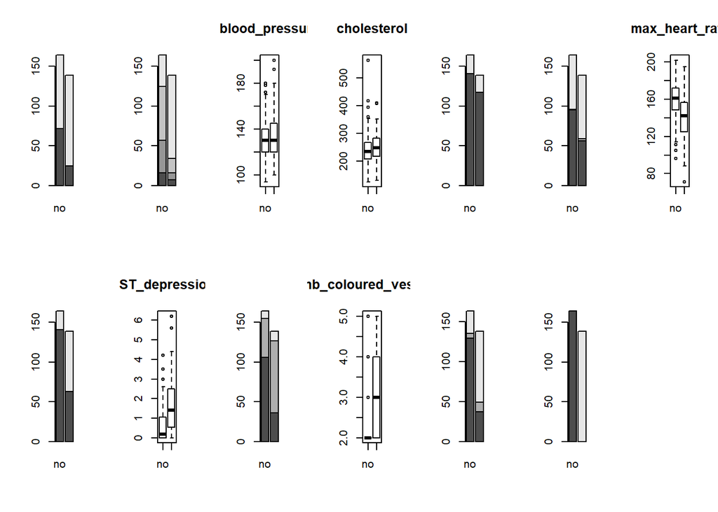

```r
par(mfrow=c(2,7))
for (i in 2:14) {
 if(is.factor(cardiac[,i])==FALSE){boxplot(cardiac[,i] ~ cardiac$disease)
 title(main=dimnames(cardiac)[[2]][i])}
  else{
      barplot(table(cardiac[,i],cardiac$disease))
    }
}
```

A partir du tableau, construire un échantillon d’apprentissage (70%) cardiac.train et un échantillon test cardiac.test (30%).

```r
set.seed(1234)
ind <- sample(2, nrow(cardiac), replace=TRUE, prob=c(0.7, 0.3))
cardiac.train <- cardiac[ind==1,]
cardiac.test <- cardiac[ind==2,]
```

En utilisant l’échantillon d’apprentissage, construire un arbre de décision avec la fonction rpart et le sauver dans un objet R.

```r
arbre_defaut<-rpart(disease ~ .,data=cardiac.train, method="class")

print(arbre_defaut)
```

```
## n= 219
##
## node), split, n, loss, yval, (yprob)
##       * denotes terminal node
##
##  1) root 219 100 no (0.54337900 0.45662100)
##    2) max_heart_rate>=150.5 122  29 no (0.76229508 0.23770492)
##      4) ST_depression< 2.25 114  22 no (0.80701754 0.19298246)
##        8) nb_coloured_vessels< 2.5 81   8 no (0.90123457 0.09876543) *
##        9) nb_coloured_vessels>=2.5 33  14 no (0.57575758 0.42424242)
##         18) chest_pain=typical angina,atypical angina,non-anginal pain 24   6 no (0.75000000 0.25000000) *
##         19) chest_pain=asymptomatic 9   1 yes (0.11111111 0.88888889) *
##      5) ST_depression>=2.25 8   1 yes (0.12500000 0.87500000) *
##    3) max_heart_rate< 150.5 97  26 yes (0.26804124 0.73195876)
##      6) ST_depression< 0.7 27  11 no (0.59259259 0.40740741)
##       12) exercise_angina=no 17   3 no (0.82352941 0.17647059) *
##       13) exercise_angina=yes 10   2 yes (0.20000000 0.80000000) *
##      7) ST_depression>=0.7 70  10 yes (0.14285714 0.85714286) *
```

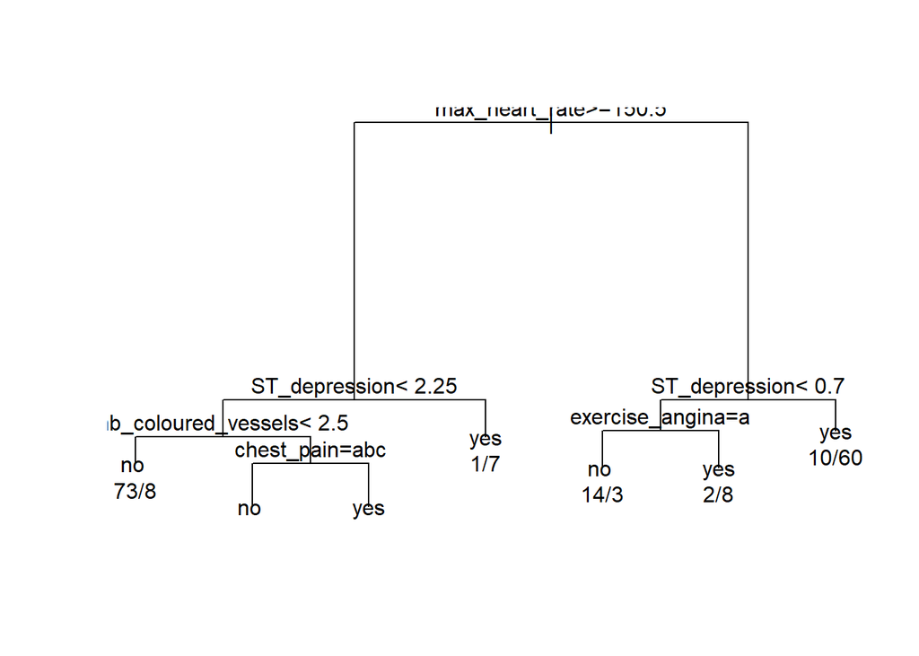

```r
plot(arbre_defaut)
text(arbre_defaut, use.n=TRUE)
```

En utilisant la fonction predict1 sur l’arbre, prédire la classe pour les individus de l’échantillon test que vous avez construit. Calculer le pourcentage de bien classés par cet arbre.

```r
pred_defaut_test<-predict(arbre_defaut,type="class", newdata=cardiac.test)
tab<- table(pred_defaut_test,cardiac.test[,14])
print("matrice de confusion")
```

```
## [1] "matrice de confusion"
```

```r
print(tab)
```

```
##
## pred_defaut_test no yes
##              no  35   7
##              yes 10  32
```

```r
print("Calcul du pourcentage de bien classés.")
```

```
## [1] "Calcul du pourcentage de bien classés."
```

```r
print(100*sum(diag(matrix(tab,2,2)))/sum(tab))
```

```
## [1] 79.7619
```